# Администрирование сетевых подсистем

Лабораторная работа №10

Четвергова Мария Викторовна

kulyabov-ds@rudn.ru

Российский университет дружбы народов

2025-11-08

# Информация

## Докладчик

- Четвергова Мария Викторовна
- Студент 3 курса
- факультет физико-математических и естественных наук
- Российский университет дружбы народов им. П. Лумумбы
- 1132231886@rudn.ru

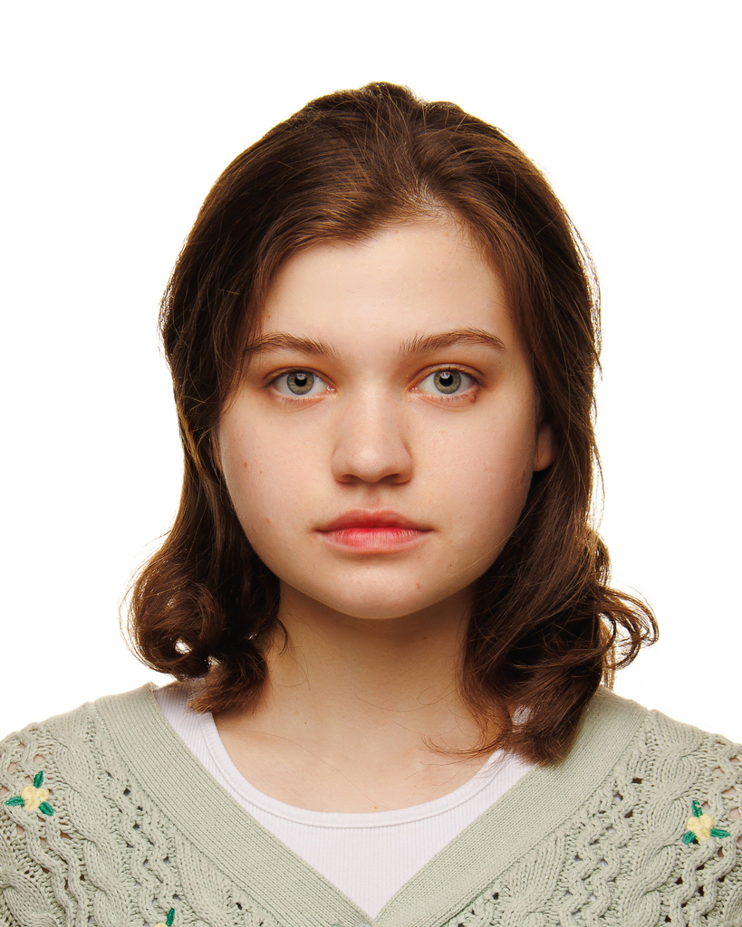

Рисунок 1

# Цель работы

## Цель работы

Целью данной лабораторной работы является приобретение практических навыков по конфигурированию SMTP-сервера в части настройки аутентификации.

# Формулировка задания

## Формулировка задания

Настроить Dovecot для работы с LMTP, аутентификацию через SASL, работу SMTP поверх TLS и скорректировать скрипты Vagrant.

# Порядок выполнения работы

## Настройка LMTP в Dovecot

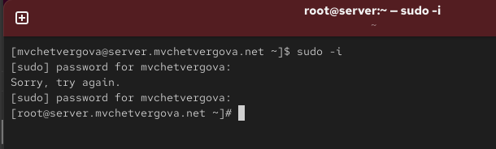

Рисунок 2: Переход в режим суперпользователя

## Настройка LMTP в Dovecot

Добавление протокола LMTP в список поддерживаемых протоколов Dovecot.

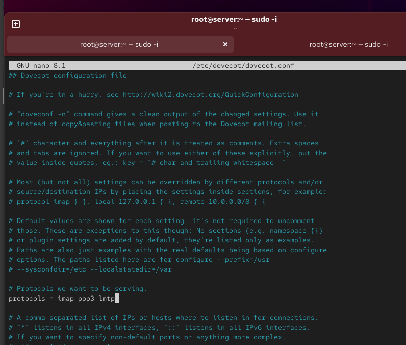

Рисунок 3: Добавление LMTP в список протоколов

## Настройка LMTP в Dovecot

Настройка сервиса LMTP для связи с Postfix через Unix-сокет.

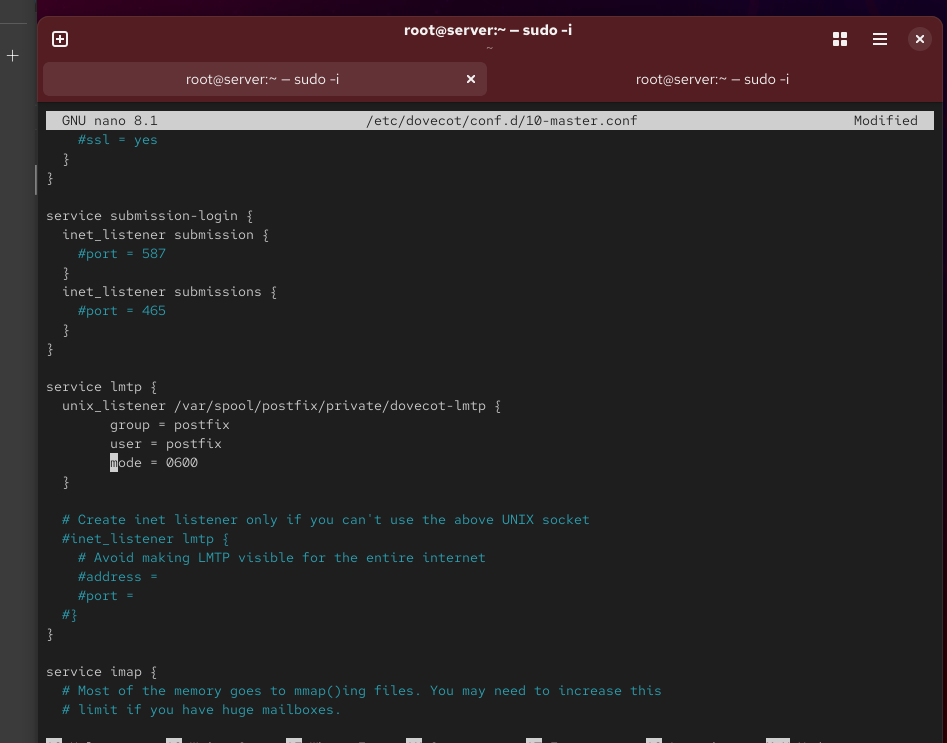

Рисунок 4: Настройка сервиса LMTP

## Настройка LMTP в Dovecot

Настройка передачи почтовых сообщений через LMTP-сокет.

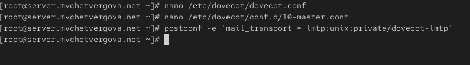

Рисунок 5: Настройка передачи через LMTP

## Настройка LMTP в Dovecot

Установка формата имени пользователя без указания домена для аутентификации.

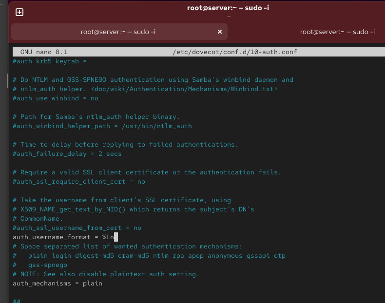

Рисунок 6: Установка формата имени пользователя

## Настройка LMTP в Dovecot

Перезапуск служб Postfix и Dovecot для применения изменений.

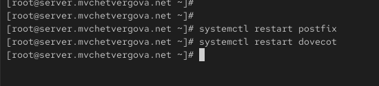

Рисунок 7: Перезапуск служб

## Настройка LMTP в Dovecot

Отправка тестового письма для проверки работы LMTP.

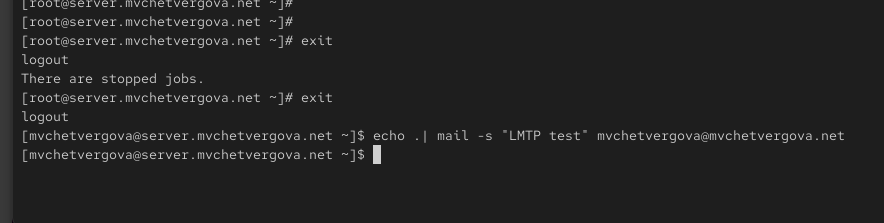

Рисунок 8: Отправка тестового письма

## Настройка LMTP в Dovecot

Отображение обработки письма в системных логах.

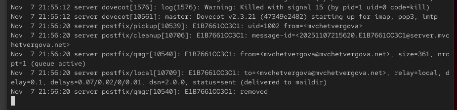

Рисунок 9: Отображение отправки письма в логе

## Настройка LMTP в Dovecot

Проверка доставки тестового письма в почтовый ящик пользователя.

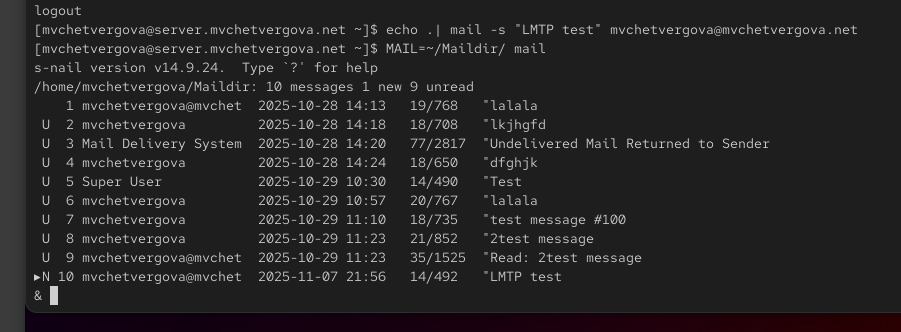

Рисунок 10: Проверка почтового ящика

## Настройка SMTP-аутентификации

Настройка службы аутентификации с созданием Unix-сокетов для взаимодействия.

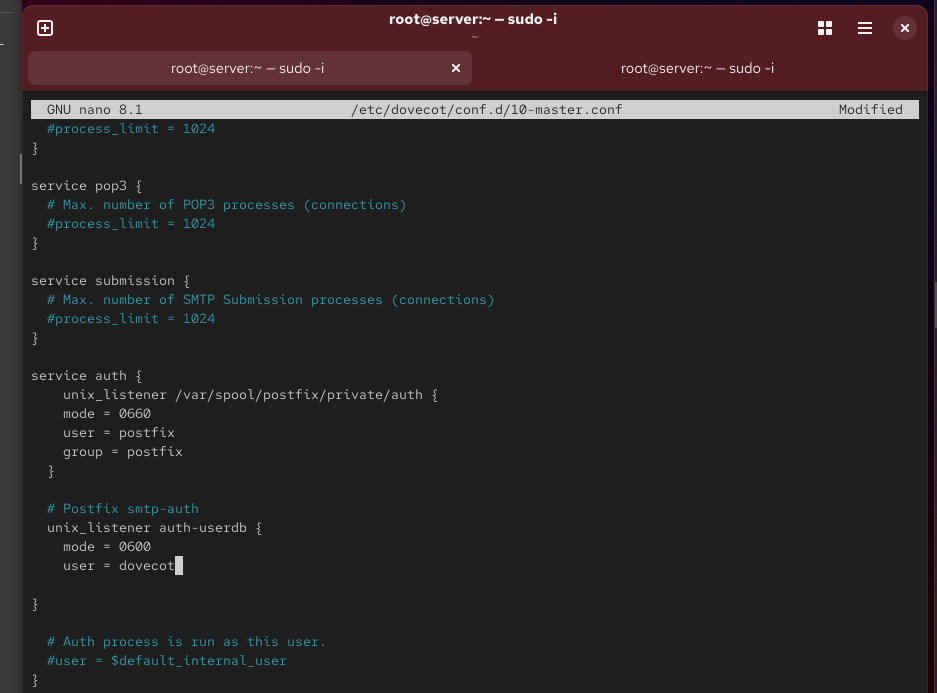

Рисунок 11: Настройка службы аутентификации

## Настройка SMTP-аутентификации

Настройка типа аутентификации SASL и пути к сокету для Dovecot.

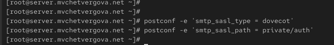

Рисунок 12: Настройка SASL в Postfix

## Настройка SMTP-аутентификации

Установка ограничений для предотвращения использования сервера как открытого релея.

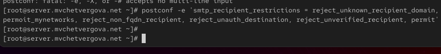

Рисунок 13: Настройка ограничений для получателей

## Настройка SMTP-аутентификации

Ограничение приема почты только из локальной сети.

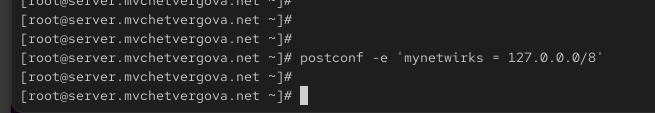

Рисунок 14: Ограничение приёма почты

## Настройка SMTP-аутентификации

Включение SASL-аутентификации и настройка ограничений в master.cf.

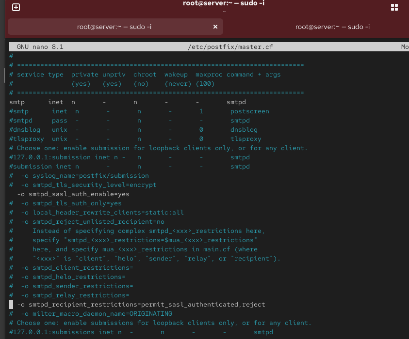

Рисунок 15: Настройка SMTP с аутентификацией

## Настройка SMTP-аутентификации

Перезапуск служб для применения изменений конфигурации.

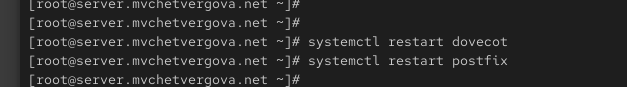

Рисунок 16: Перезапуск служб

## Настройка SMTP-аутентификации

Установка утилиты telnet на клиентской машине для тестирования.

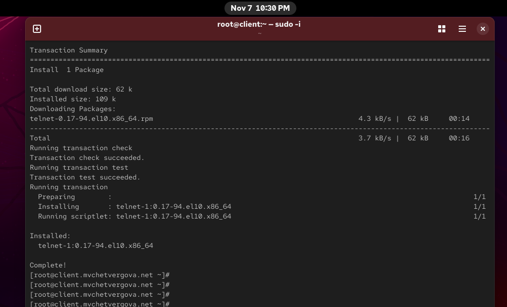

Рисунок 17: Установка telnet

## Настройка SMTP-аутентификации

Генерация строки для аутентификации в формате base64.

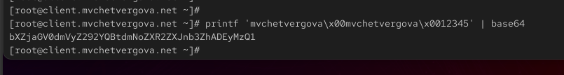

Рисунок 18: Генерация строки аутентификации

## Настройка SMTP-аутентификации

Установка подключения к SMTP-серверу на порту 25 через telnet.

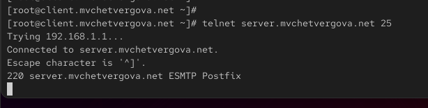

Рисунок 19: Подключение к SMTP-серверу через telnet

## Настройка SMTP-аутентификации

Тестирование соединения командой EHLO, подтверждение поддержки аутентификации.

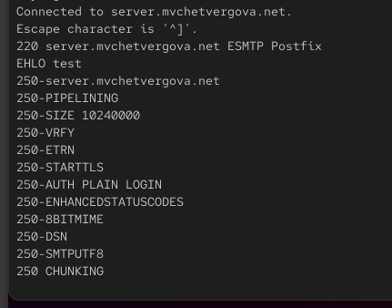

Рисунок 20: Тестирование соединения командой EHLO

## Настройка SMTP-аутентификации

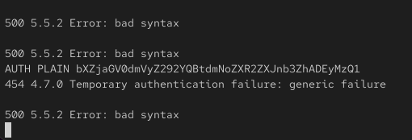

## Настройка SMTP over TLS

Копирование TLS-сертификатов в соответствующие каталоги.

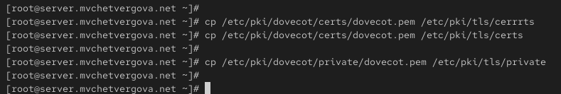

Рисунок 22: Копирование TLS-сертификатов

## Настройка SMTP over TLS

Настройка параметров TLS в Postfix.

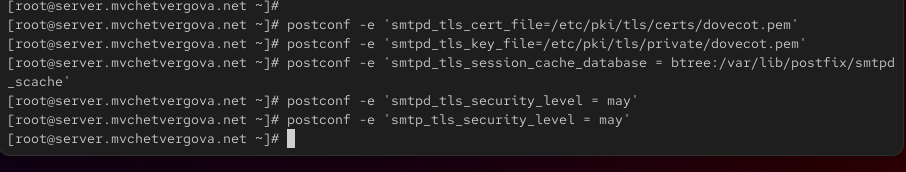

Рисунок 23: Настройка TLS в Postfix

## Настройка SMTP over TLS

Настройка порта 587 с обязательным TLS-шифрованием и аутентификацией.

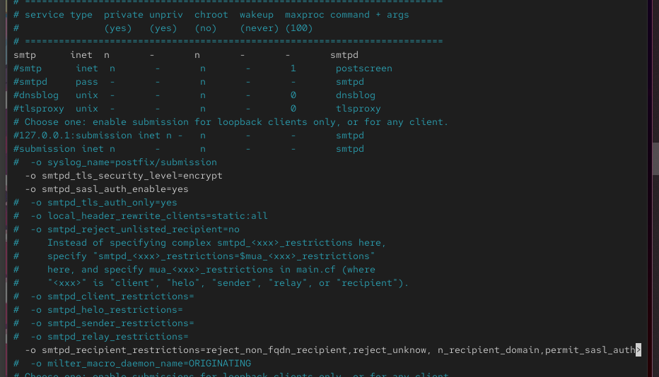

Рисунок 24: Настройка порта 587 с TLS

## Настройка SMTP over TLS

Разрешение работы службы smtp-submission в firewall.

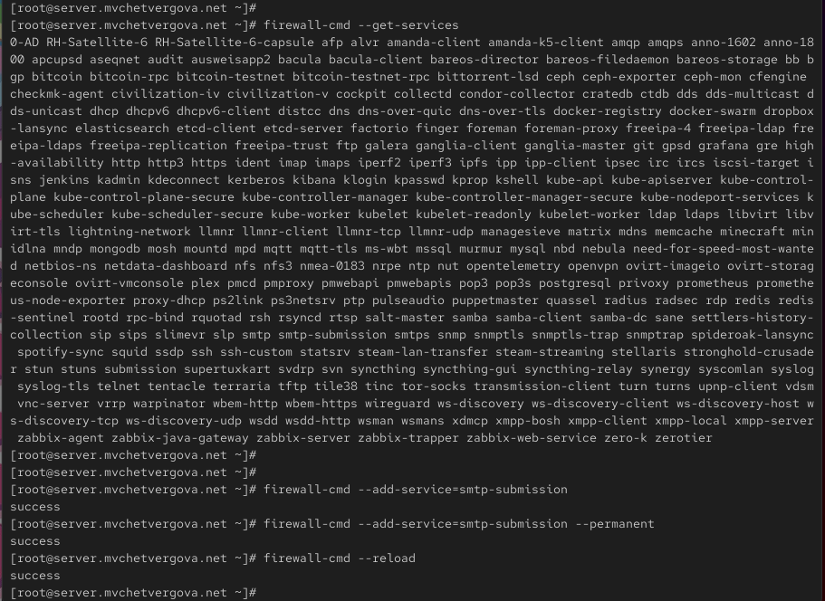

Рисунок 25: Настройка firewall

## Настройка SMTP over TLS

Перезапуск Postfix для применения TLS-конфигурации.

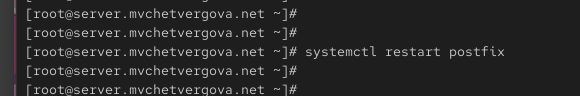

Рисунок 26: Перезапуск Postfix

## Настройка SMTP over TLS

Установка защищенного подключения к SMTP через openssl на порту 587.

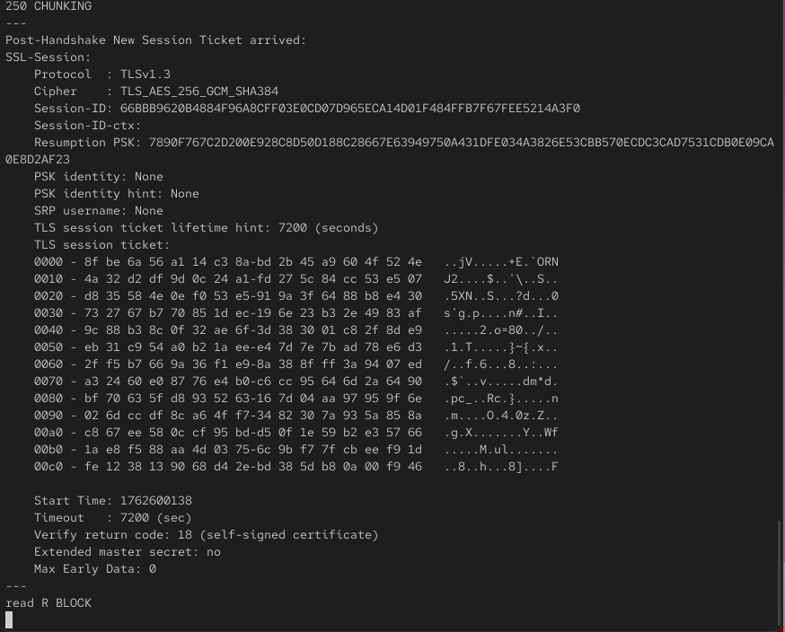

Рисунок 27: Подключение к SMTP через openssl

## Настройка SMTP over TLS

Тестирование подключения командой EHLO через TLS-соединение.

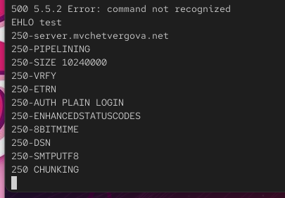

Рисунок 28: Тестирование подключения командой EHLO

## Настройка SMTP over TLS

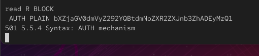

## Внесение изменений в настройки внутреннего окружения виртуальной машины

Копирование конфигурационных файлов в директорию provisioning.

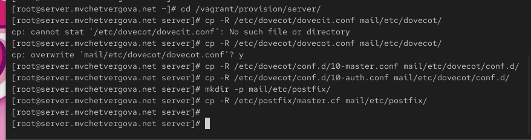

Рисунок 30: Копирование конфигурационных файлов

## Внесение изменений в настройки внутреннего окружения виртуальной машины

Обновление скрипта mail.sh с учетом всех настроек SMTP-сервера.

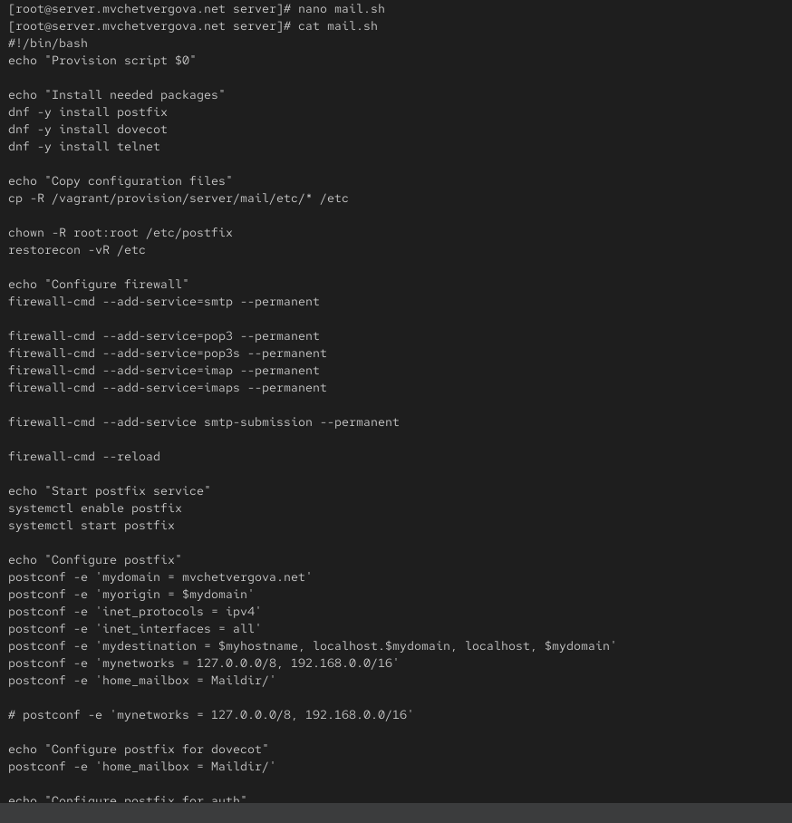

Рисунок 31: Изменения в скрипте mail.sh

## Внесение изменений в настройки внутреннего окружения виртуальной машины

Добавление установки telnet в скрипт клиента для тестирования.

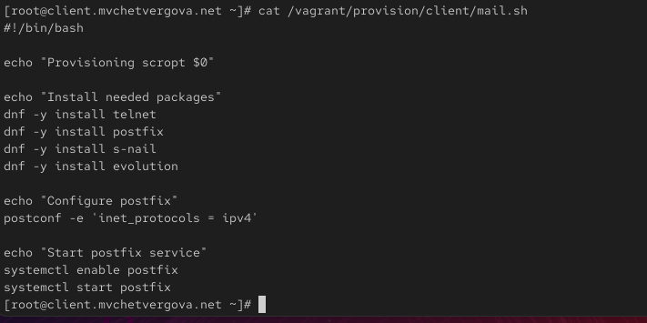

Рисунок 32: Изменения в скрипте клиента

## Список литературы

1. Postfix SASL Howto. — URL: http://www.postfix.org/SASL_README.html
2. Dovecot Documentation: LMTP. — URL: https://doc.dovecot.org/configuration_manual/protocols/lmtp_server/
3. RFC-4422: Simple Authentication and Security Layer (SASL). — URL: https://tools.ietf.org/html/rfc4422
4. Postfix TLS Support. — URL: http://www.postfix.org/TLS_README.html
5. Dovecot Authentication. — URL: https://doc.dovecot.org/configuration_manual/authentication/